# I declare **WAR**! Wait what is WAR, anyway?

Steffaney Cohen

8/13/2020

The *sabermetric* WAR stands for “Wins Above Replacement” which is a metric meant to encompass a player’s total contributions to their team. It’s useful for comparing players. If a player had to be replaced by an available substitute, their WAR score would let the team know how much value is lost and a way to evaluate potential replacements. WAR is expressed in a wins format, such that if a player’s WAR is +5, this means the player’s contributions gains 5 wins for the team.

[Within the calculation of WAR](https://library.fangraphs.com/war/calculating-war-pitchers/) for pitchers is FIP (Fielding Independent Pitching) which is a measure of a pitcher’s responsibility for runs allowed.

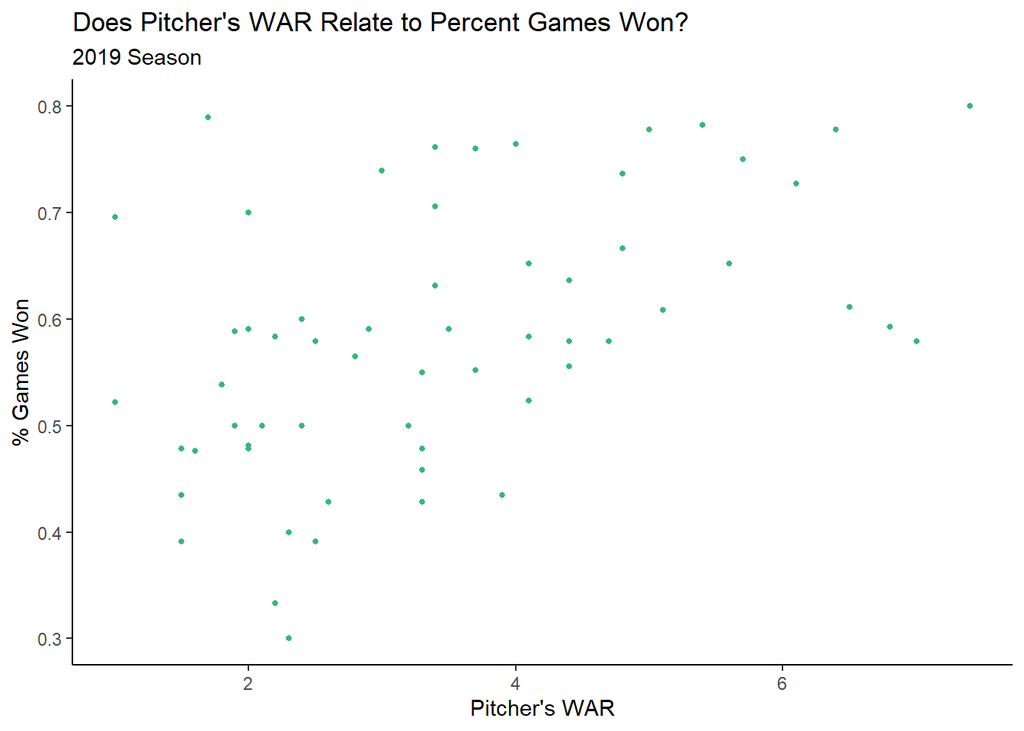

**What Teams Won the War of the WAR’s in 2019?** Below we see the number of pitchers by team that were above the average WAR for 2019. The Astros had a pitchers that are well above average WAR.

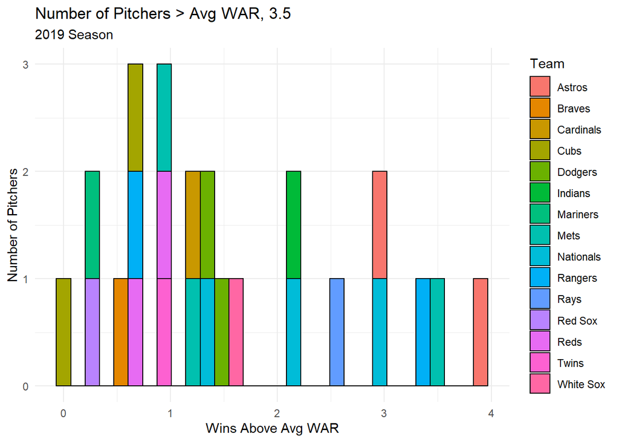

**What Teams Lost the War of the WAR’s in 2019?** Below we see the number of pitchers by team that were at or below the average WAR for 2019. The Cardinals had pitchers that were well below average WAR.

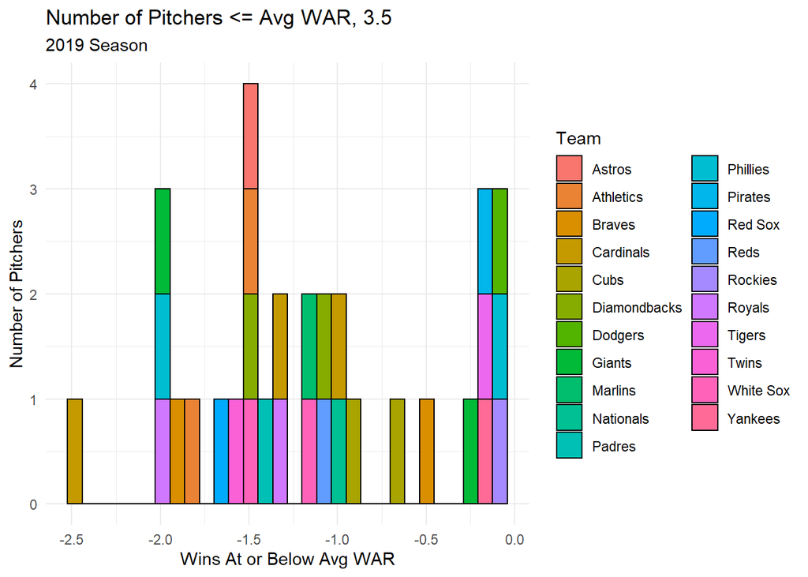